# Flight Cancellation Predictors

## by Kevin Wu Almanzar

## Investigation Overview

In this investigation, I wanted to look different features and see how well they could be used to predict flight cancellations.

## Dataset Overview

The dataset used contained flight attributes for almost 2,389,217 flights that occurred in 2008. To reduce runtime and to narrow this exploration, only the month of January was analyzed, which has 605,765 entries. Once we look at only cancelled flights, the attributes are reduced to 8 variables (including the cancellation variable) as a lot of data is not collected once a flight is cancelled (e.g. Actual Arrival Time).

## Distribution of Cancelled and Non-Cancelled Flights

There are approximately 600,000 entries. Of the 600,00 entries only a small fraction make up cancelled flights.

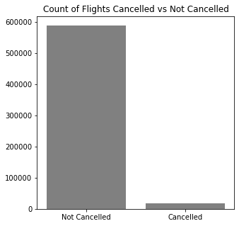

## Cancelled Flight Rate by Carrier

Cancelled flights are higher for some airline carriers. While rates are only single digit, they may add up with other factors.

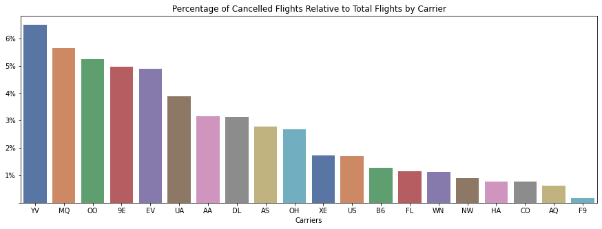

## Cancelled Flight Rates by Specific Planes

Specific planes (identified by their Tail Number) can be a good indicator of whether a flight will be cancelled. Some planes have cancellation rates up to ~26%.

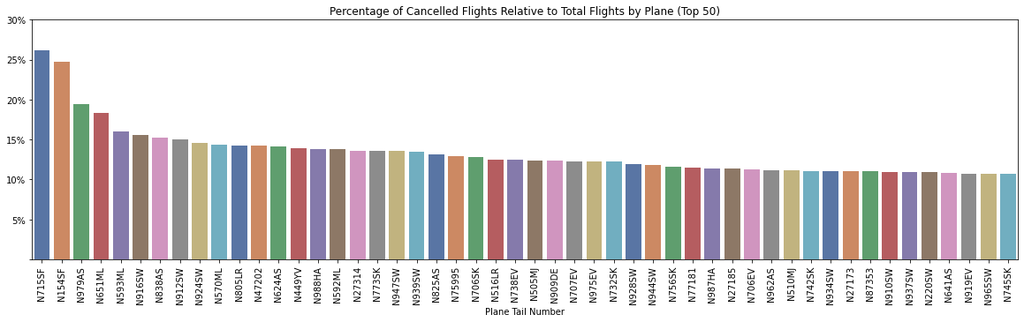

## Combination Effects between Carriers and Specific Planes

When planes with the most cancellations are identified and classified by carriers, a pattern is shown where these planes are owned by a few carriers. These carriers are also in the top 10 carriers for cancellation rates.

These two factors are likely related and likely strengthen each other due to overlap. The streghtening factor was not explored.

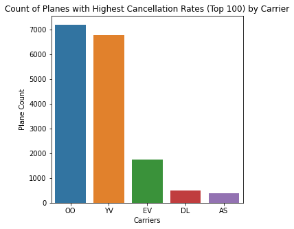

## Cancelled Flight Rates by Origin

Certain destinations have cancellation rates up to 31%, which can be used to predict whether a flight will be cancelled.

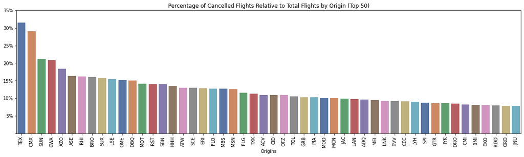

## Cancelled Flight Rates by Destination

Certain destinations have cancellation rates up to 26%, which can be used to predict whether a flight will be cancelled.

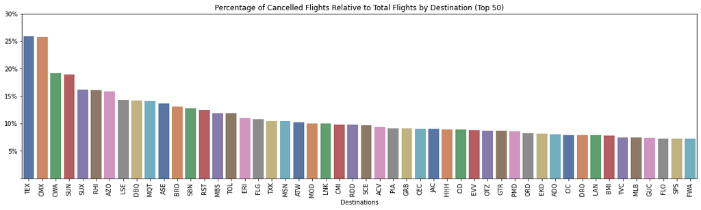

## Cancelled Flight Rate Combining Origin and Destination

While specific airports may be used to try to predict cancellations, specific routes may be a better indicator with cancellation rates reaching up to ~30% for specific routes. These specific routes will strengthen or weaken the cancellation rates for individual origins or destinations.

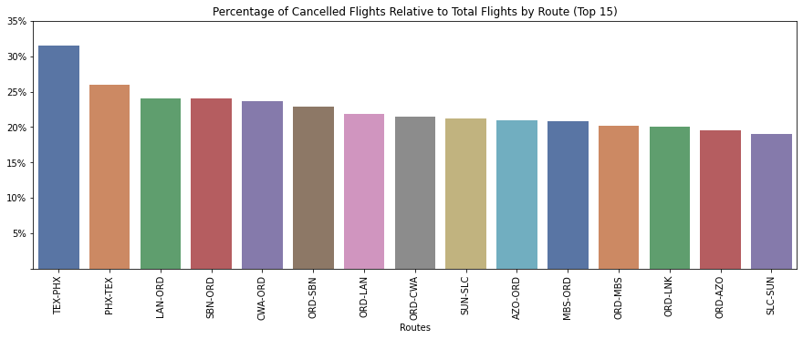

## Main Takeaways:

#### - The best indicators for cancellations appear to be specific routes and planes with double digit cancellation rates.

#### - Carriers can also be an indicator of flight cancellations, but it is a weaker indicator with single digit cancellation rates.